# Seminar1

Robin Kirknes Andreassen

2022-10-07

```r
library("devtools")
#devtools::install_github("avehtari/ROS-Examples",subdir = "rpackage", force = TRUE)
library("rosdata")
library("tidyverse")
```

# Oppgave 1

```r
earnings <- earnings
names(earnings)
```

```
##  [1] "height"           "weight"           "male"             "earn"
##  [5] "earnk"            "ethnicity"        "education"        "mother_education"
##  [9] "father_education" "walk"             "exercise"         "smokenow"
## [13] "tense"            "angry"            "age"
```

**Hvilke variabler inneholder det?**

Height, weight, male, earn, earnk, ethnicity, education, mother’s education, farther’s education, walk, exercise, smokenow, tense, angry, age

**Hvor mange observasjoner inneholder det?**

1816 observasjoner

# Oppgave 2

**Lag tetthetsplot for inntektsvariabelen “earn”**

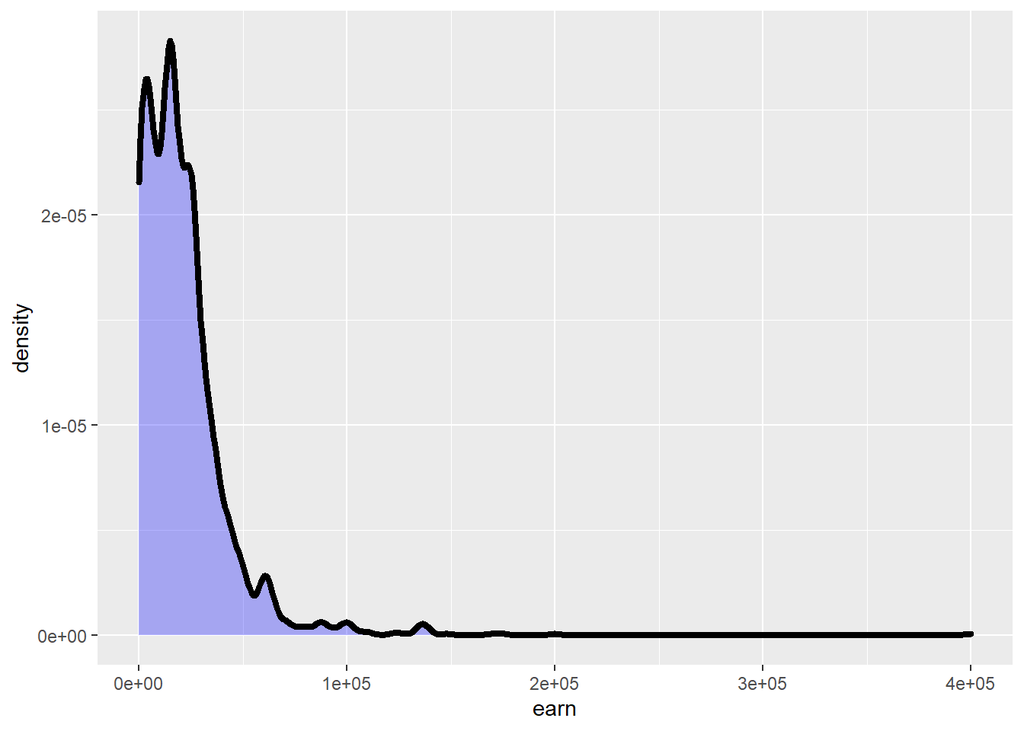

```r
ggplot(data = earnings, aes(earn)) + geom_density(size=1.5, fill="blue", alpha=0.3)
```

**Vurder om det kan være hensiktsmessig å transformere variabelen. Lag i såfall et nytt plot**

Det kan være nyttig å endre logaritmen (hvis jeg har forstått det konseptet riktig) slik at vi kan endre skalaforholdet og tydeligere se fordelingen.

Tallene på X- og Y-aksen gir ikke mye mening, hvordan kan man få dette til å bedre representere tallene i selve variabelen?

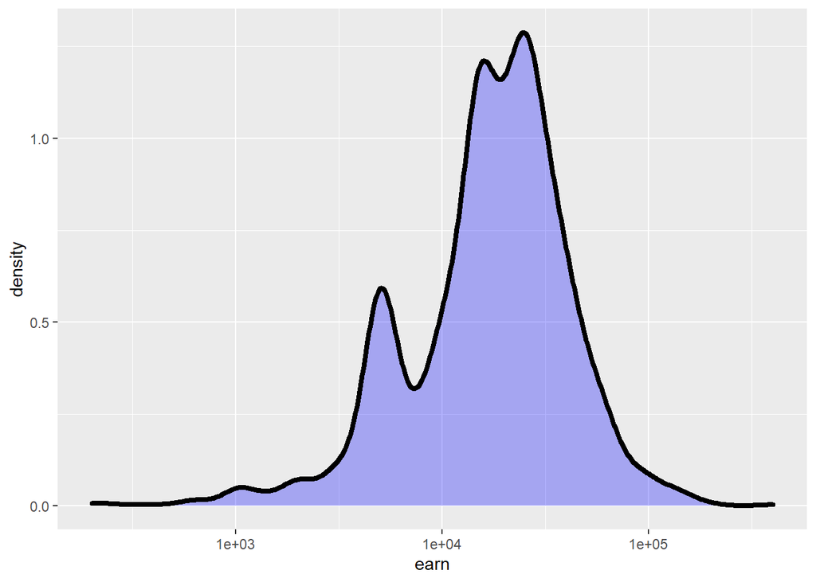

```r
ggplot(data = earnings, aes(earn)) + geom_density(size=1.5, fill="blue", alpha=0.3) + scale_x_log10()
```

#Oppgave 3

**Kod om kjønnsvariabelen til en faktorvariabel**

```r
earnings$factorvariabel <- ifelse(earnings$male == 1, "male", "female")
```

**Lag et nytt plott som skiller menn og kvinner, slik at du får to fordelinger i ett plott**

Har ikke peiling på hvordan jeg får det i ett plott

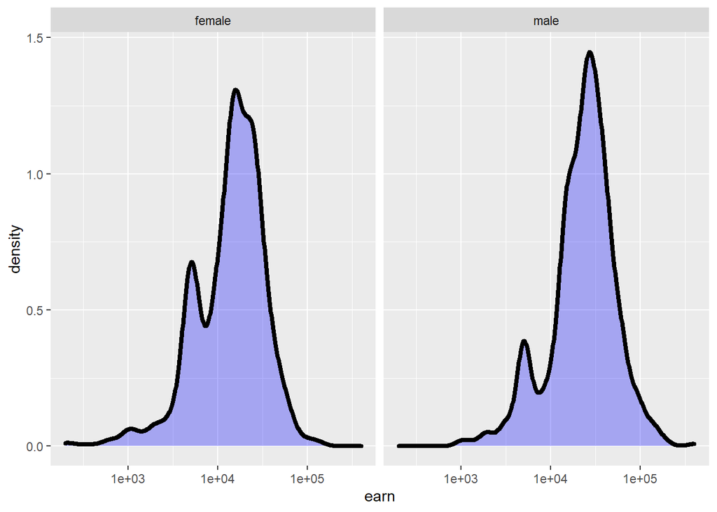

```r
ggplot(data = earnings, aes(earn)) + geom_density(size=1.5, fill="blue", alpha=0.3) + scale_x_log10() + facet_wrap(vars(factorvariabel))
```

**Legg til vertikale linjer som viser medianinntekten for hvert kjønn**

```r
#ggplot(data = earnings, aes(earn)) + geom_density(size=1.5, fill="blue", alpha=0.3) + scale_x_log10() + facet_wrap(vars(factorvariabel)) + geom_vline()
```

Jeg vet ikke hvordan jeg skal klare å regne ut median på en variabel for så å bruke det i geom_vline, arbeidsbøkene var ikke noe hjelp heller